# HOMEWORK 1

### EM clustering

Let’s try clustering based on probability distributions.

```r
res.Mclust = Mclust(scale(X))
summary(res.Mclust)
```

```
## ----------------------------------------------------
## Gaussian finite mixture model fitted by EM algorithm
## ----------------------------------------------------
##
## Mclust VEV (ellipsoidal, equal shape) model with 8 components:
##
##  log-likelihood    n  df       BIC       ICL
##        -12679.3 1952 989 -32851.87 -32982.43
##
## Clustering table:
##   1   2   3   4   5   6   7   8
## 131 139 289 218 404 285 287 199
```

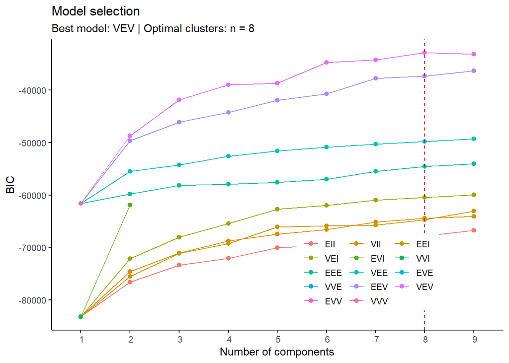

```r
fviz_mclust(object = res.Mclust, what = "BIC", pallete = "jco") +
  scale_x_discrete(limits = c(1:10))
```

We have an interesting optimal number of clusters, as the method is suggesting 8 Clusters as the optimal number.

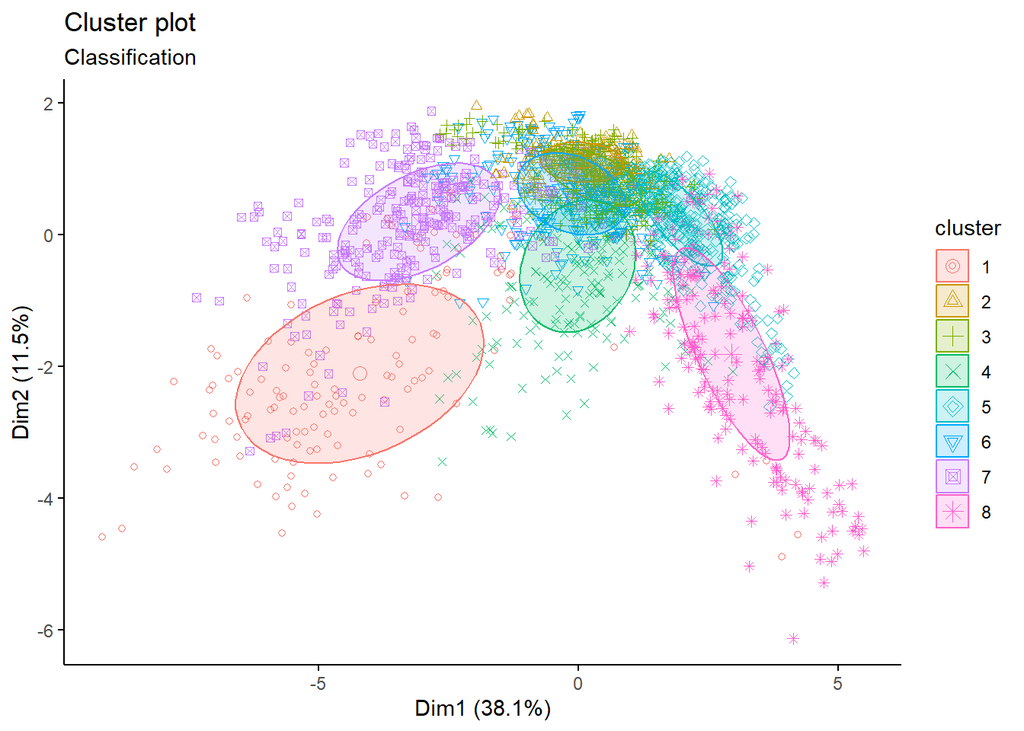

```r
# visualize the 8 clusters
fviz_mclust(object = res.Mclust, what = "classification", geom = "point",
            pallete = "jco")
```

As the number of optimal cluster has changed, we expect to have low similarity with the PAM clusterization. Let’s check it.

```r
adjustedRandIndex(res.Mclust$classification, fit.pam$clustering)
```

```
## [1] 0.1039571
```

Now, we visualize how the 8 clusters would look like in a map.

```r
groups.mclust = res.Mclust$classification

map = data.frame(
  country = data$Country,
  value = groups.mclust
)

map$country = countrycode(map$country, 'country.name', 'iso3c')

# join clustering data with world map
matched = joinCountryData2Map(
  map,
  joinCode = "ISO3",
  nameJoinColumn = "country"
)
```

```
## 1952 codes from your data successfully matched countries in the map
## 0 codes from your data failed to match with a country code in the map
## 61 codes from the map weren't represented in your data
```

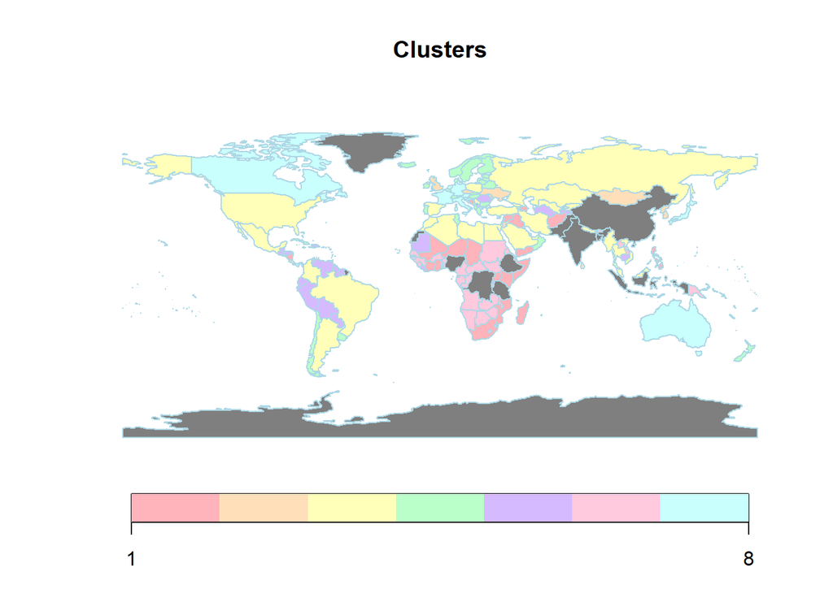

```r
# plot the map
mapCountryData(
  matched,
  nameColumnToPlot = "value",
  missingCountryCol = "grey50",
  borderCol = "lightblue",
  catMethod = "pretty",
  colourPalette = c(
  "#FFB3BA",
  "#FFDFBA",
  "#FFFFBA",
  "#BAFFC9",
  "#D5BAFF",
  "#FFC9DE",
  "#C9FFFC"
),
  mapTitle = "Clusters",
  lwd = 1
)
```

We have not found any more interesting conclusions like the `Measles` from this other forms of clusterization.

## CONCLUSION

We have uncovered interesting insights and significantly enhanced our understanding of this dataset, particularly the relationships between key health and socioeconomic indicators. Through the application of Unsupervised Learning techniques, such as Factor Analysis, Principal Component Analysis and Clustering, we have identified patterns and influential observations that challenge assumptions about linear relationships, such as the unexpected behavior of measles rates in highly developed countries. This analysis have not only improved our knowledge of the dataset, but also strengthened our skills in leveraging unsupervised learning methods for exploratory data analysis.

# Bibliography

```r
# map
# https://r-spatial.org/r/2018/10/25/ggplot2-sf.html
# animations
# https://gganimate.com/
# 3D graph
# https://r-graph-gallery.com/3d_scatter_plot.html
# embed 3D graph to html
# https://stackoverflow.com/questions/63595786/rmarkdown-how-to-embed-an-3d-plot
# identify influential data points
# https://www.statology.org/how-to-identify-influential-data-points-using-cooks-distance/#:~:text=A%20data%20point%20that%20has,considered%20to%20be%20an%20outlier.
```

We have also used the notebooks provided in class.